### **Using the trial conduct interface**

Upon clicking **Trial conduct** in the sidebar, you will be greeted with the empty interface.

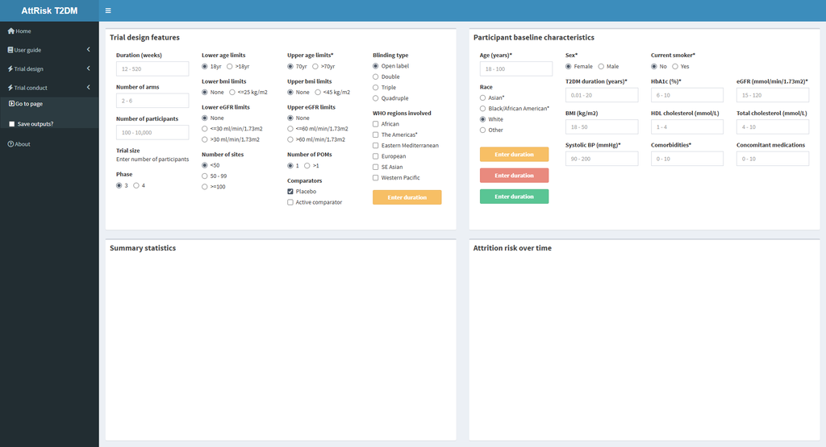

Three buttons controlling the interface are found at the bottom of **Box B**:

By default, all buttons are disabled all numeric inputs are entered (duration, number of arms, number of participants, age). Each button will display the required input to indicate this as other numeric inputs are entered.

Once all numeric inputs are entered, the buttons will activate.

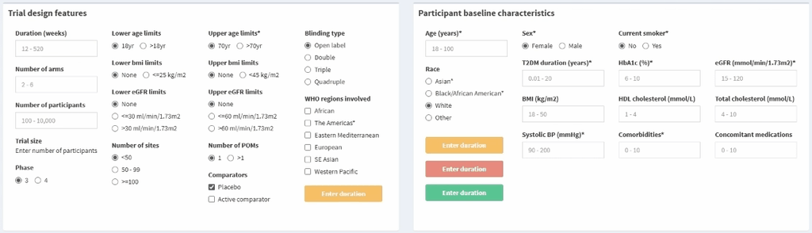

After pressing **Predict risk**, outputs will be generated in boxes C and D after a couple of seconds.

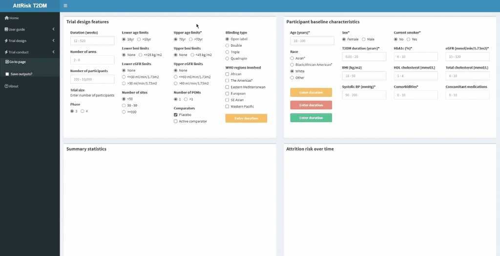

### **Save the generated outputs**

The dropdown menu for **Trial conduct** also has a checkbox labelled **“Save outputs?”**.

When selected, a series of additional checkboxes will appear allowing for the plot and summary statistics to be downloaded.

An Excel CSV file will be saved by default with any selected output. This contains the design features and participant characteristics inputted to generate the outputs (**features_characteristics.csv**)

After selecting the desired outputs to save, press **Save outputs**. A loading bar in the bottom-right corner of the interface indicating the preparation of outputs.

Shortly after, a popup will appear indicating that the outputs are ready to download. Click **Download zip** to save the outputs to your computer.

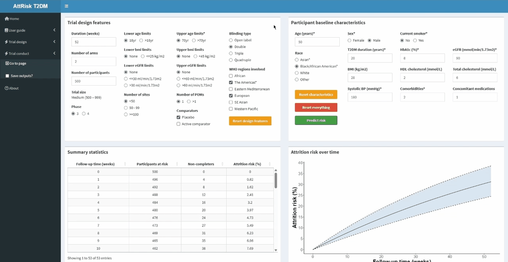

Click **Close** to return to the interface.